# PA1_tepmlate.Rmd

Michaela May

9 juillet 2017

# Assignment

## Load the data

```r
activity<- read.csv("activity.csv")

activity$date <- as.Date(activity$date, "%Y-%m-%d")

library(dplyr)
dailysteps <- activity%>%group_by(date)%>%summarize(steps=sum(steps, na.rm=TRUE))
```

## What is the mean total number of steps taken per day?

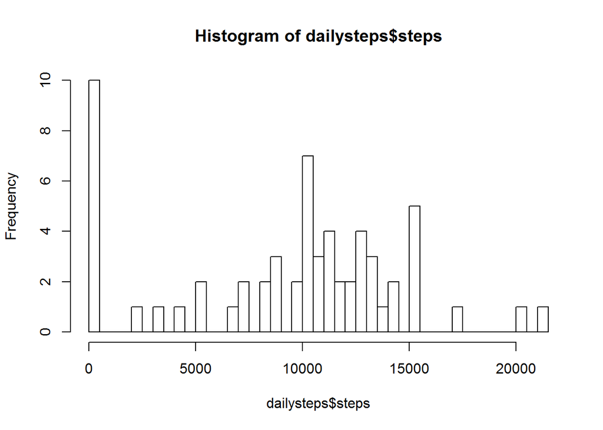

```r
hist(dailysteps$steps, breaks = 50)
```

## What are the mean and the median number of steps taken per day?

```r
mymean <- mean(dailysteps$steps)
mymedian <- median(dailysteps$steps)
```

The mean is 9354.2295082 and the median is 10395.

## what is the average daily activity pattern?

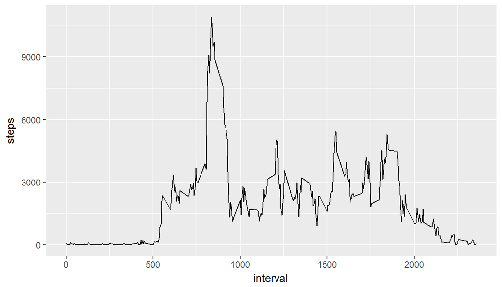

```r
minutesteps <- activity%>%group_by(interval)%>%summarize(steps=sum(steps, na.rm=TRUE))

library(ggplot2)
qplot(interval,steps, data = minutesteps, geom="line")
```

```r
moststeps<- minutesteps$interval[which(minutesteps$steps==max(minutesteps$steps))]
```

## Imputing missing values

```r
myna <- sum(is.na(activity))
```

In order to treat missing values, we will assume that they have the same value as the average in the same interval.

```r
library(dplyr)

avgsteps <- activity%>%group_by(interval)%>%summarize(steps=mean(steps, na.rm=TRUE))

activity2 <- inner_join(activity,avgsteps, by=c("interval"="interval"))

imputedsteps <- replace(activity2$steps.x,is.na(activity2$steps.x),activity2$steps.y[is.na(activity2$steps.x)])

activity3 <- mutate(activity2, steps = imputedsteps)

newactivity <- activity3[,c(5,2,3)]
```

Above, we have created a new data set, where missing values have been replaced by the average values on other days in the same time interval. How does the histogram for steps per day change?

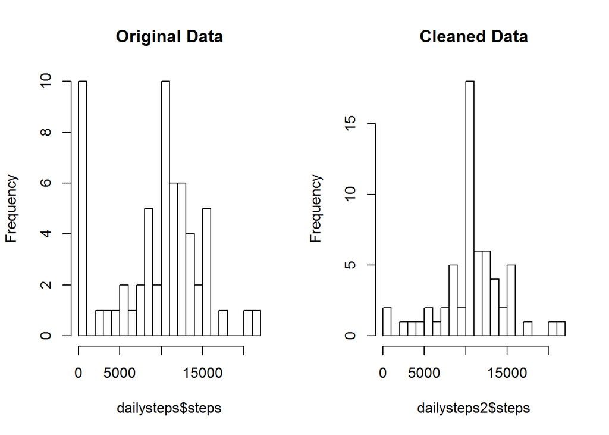

```r
dailysteps2 <- newactivity%>%group_by(date)%>%summarize(steps=sum(steps, na.rm=TRUE))

par(mfrow=c(1,2))
hist(dailysteps$steps, breaks = 20, main = "Original Data")
hist(dailysteps2$steps, breaks = 20, main = "Cleaned Data")
```

The imputing of missing values has increased the number of daily steps

```r
### imputed mean & median
mymean2 <- mean(dailysteps2$steps)
mymedian2 <- median(dailysteps2$steps)
```

## Are there differences in activity patterns between weekdays and weekends?

Let’s have a look if there is a difference between weekend and weekdays in the step pattern?

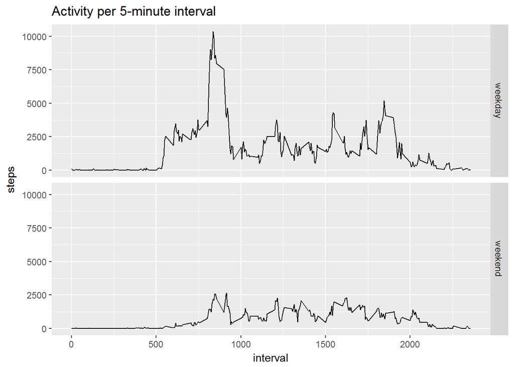

```r
weekfac <- as.factor(ifelse(weekdays(newactivity$date) %in% c("samedi","dimanche"),"weekend","weekday"))
newactivity2 <- mutate(newactivity, wday = weekfac)
intervalnew <- newactivity2%>%group_by(interval,wday)%>%summarize(steps=sum(steps, na.rm=TRUE))

par(mfrow = c(2,1))
qplot(interval,steps, data = intervalnew, geom="line", main="Activity per 5-minute interval", facets = wday~.)
```